# Introduction à R

## Statistiques descriptives et analyses univariées

Une fois votre banque de données bien “nettoyée”, vous pouvez vous lancer dans l’analyse statistique. Une première étape pertinente est d’explorer vos données de façon descriptive ou de faire des analyses sur une variable à la fois (univariées). Par exemple:

```r
> # Tableaux de fréquences
> table(travail.femmes$k618)
```

```
##
##   0   1   2   3   4   5   6   7   8
## 258 185 162 103  30  12   1   1   1
```

Ce type de tableau, avec les fréquences à l’horizontal, n’est peut-être pas le plus intuitif, surtout si la variable qui vous intéresse a beaucoup de catégories. Pour remédier à la situation, nous utiliserons la fonction `count()`.

```r
> # Exécutons la fonction suivante
> count(travail.femmes$k618)
```

R devrait renvoyer un message d’erreur. La fonction `count()` est introuvable. La raison est la suivante: R contient en tout temps certaines fonctions de base, comme celles que nous avons utilisées depuis le début de cet atelier (`setwd()`, `table()`, `mean()`, etc.). Or, pour utiliser d’autres fonctions, il est nécessaire d’installer des paquets (*packages*). Il existe des centaines de paquets, que les collaborateurs et collaboratrices du langage R travaillent à développer. Ces paquets contiennent des fonctions qui vous permetteront de réaliser diverses actions. Souvent, la seule manière pour vous de connaître l’existence d’une fonction (et de son paquet) sera de faire des recherches sur internet.

Ma recherche internet m’indique que la fonction `count()` se trouve dans le paquet nommé `plyr`. Installons-le.

```r
> install.packages("plyr")
```

La deuxième étape essentielle est d’ “appeler” le paquet à l’aide de la fonction `library()`.

```r
> library(plyr)
```

Il faut voir la fonction `library()` comme un service de bibliothécaire (littéralement). Après avoir installé le *package* `plyr`, ce dernier se trouvait en mémoire de R. Cependant, il vous était encore impossible de l’utiliser parce que vous ne l’aviez pas “fait venir à la surface”.

Maintenant que tout est installé, retournons à nos statistiques descriptives:

```r
> count(travail.femmes$k618)
```

| x | freq |
| --- | --- |
| 0 | 258 |
| 1 | 185 |
| 2 | 162 |
| 3 | 103 |
| 4 | 30 |
| 5 | 12 |
| 6 | 1 |
| 7 | 1 |
| 8 | 1 |

Il est également possible de visualiser nos variables à l’aide de graphiques.

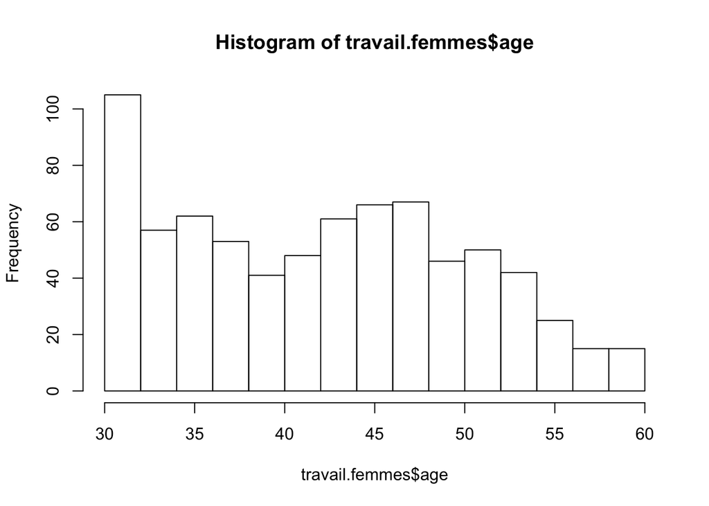

```r
> hist(travail.femmes$age)
```

Il est possible de calculer des mesures de tendances centrales, comme la moyenne et la médiane.

```r
> # Moyenne d'âge des répondantes
> mean(travail.femmes$age)
```

```
## [1] 42.53785
```

```r
>
> # Calcul de la moyenne de la variable lfp, pour connaître le nombre de
> # femmes qui sont sur le marché du travail
> mean(travail.femmes$lfp)
>
> # R renvoit un message d'erreur parce que la variable n'est pas numérique
> is.numeric(travail.femmes$lfp)
```

```
## [1] FALSE
```

```r
>
> # Je peux calculer la moyenne de la variable lfp en la dédoublant en
> # variable numérique
> travail.femmes$lfp.num = as.numeric(travail.femmes$lfp)
> table(travail.femmes$lfp.num, travail.femmes$lfp)
```

```
##
##      no yes
##   1 325   0
##   2   0 428
```

```r
>
> mean(travail.femmes$lfp.num)
```

```
## [1] 1.568393
```

```r
>
> # Âge moyen des femmes qui travaillent seulement
> mean(travail.femmes$age[travail.femmes$lfp == "yes"])
```

```
## [1] 41.97196
```

```r
>
> # Les femmes qui travaillent sont en moyenne plus jeunes que les femmes qui
> # ne travaillent pas.
>
> # Calcul de l'écart type
> mean(travail.femmes$k618)
```

```
## [1] 1.353254
```

```r
> sd(travail.femmes$k618)
```

```
## [1] 1.319874
```

```r
>
> # En moyenne, les répondantes ont 1.35 enfant de 6 à 18 ans. L'écart-type
> # associé à cette statistique est 1,32.
>
> # Je voudrais savoir le nombre total d'enfants qu'ont ces répondantes
> travail.femmes$enfants = travail.femmes$k618 + travail.femmes$k5
> count(travail.femmes$enfants)
```

| x | freq |
| --- | --- |
| 0 | 229 |
| 1 | 161 |
| 2 | 167 |
| 3 | 117 |
| 4 | 56 |
| 5 | 15 |
| 6 | 5 |
| 7 | 1 |
| 8 | 2 |

## Analyses bivariées et statistiques inférentielles

R peut servir à analyser la relation entre deux ou plusieurs variables. De nombreux tests, comme la corrélation de Pearson, sont disponibles sur R. Après avoir analysé la force de la relation entre deux variables, vous pouvez également tester la signification statistique de cette dernière à l’aide, par exemple, de tests comme le khi carré.

Première question: La participation des femmes au marché de l’emploi (`lfp`) est-elle liée au fait qu’elles aient fréquenté l’université (`wc`)?

```r
> # Faisons un tableau croisé pour visualiser la relation (potentielle)
> table(travail.femmes$lfp, travail.femmes$wc)
```

```
##
##        no yes
##   no  257  68
##   yes 284 144
```

```r
>
> # Faisons des variables numériques pour lfp et wc
> travail.femmes$wc.num = ifelse(travail.femmes$wc == "yes", 1, 0)
> travail.femmes$hc.num = ifelse(travail.femmes$hc == "yes", 1, 0)
>
> # Corrélation
> cor(travail.femmes$lfp.num, travail.femmes$wc.num)
```

```
## [1] 0.1401022
```

La corrélation entre la participation au marché de l’emploi et la fréquentation universitaire est très faible (0.14). Pour connaître le niveau de signification statistique, utilisons la fonction `rcorr()` du paquet `Hmisc`.

```r
> install.packages("Hmisc")
```

```r
> library(Hmisc)
>
> rcorr(travail.femmes$lfp.num, travail.femmes$wc.num)
```

```
##      x    y
## x 1.00 0.14
## y 0.14 1.00
##
## n= 753
##
##
## P
##   x     y
## x       1e-04
## y 1e-04
```

```r
> # rcorr nous donne la statistique p associée à chaque corrélation
> # L'association statistique entre lpf et wc est significative à ~0.0001
>
> # Pour connaître la signification statistique, on peut aussi utiliser le khi
> # carré
> chisq.test(travail.femmes$lfp.num, travail.femmes$wc.num)
```

```
##
##  Pearson's Chi-squared test with Yates' continuity correction
##
## data:  travail.femmes$lfp.num and travail.femmes$wc.num
## X-squared = 14.158, df = 1, p-value = 0.0001681
```

## Régression linéaire et analyses multivariées

Enfin, R nous permet de faire des analyses de régression par les moindres carrés ordinaires (*OLS*). Passons en revue les éléments les éléments à inclure dans la fonction `lm()`.

```r
> ?lm
```

Est-ce que le nombre d’enfants est associé au salaire des femmes? On pourrait poser l’argument selon lequel les femmes qui ont plus d’enfants ont un salaire moins élevé que les autres, puisqu’elles ont dû s’absenter du marché du travail pour une plus longue période de temps. Or, l’ancienneté et l’expérience sont généralement associées positivement au salaire, et les législations relatives à l’équité salariale et aux congés de parentalité étaient encore moins répandues en 1975.

Le salaire des femmes (`lwg`) est la variable dépendante, tandis que le nombre d’enfants (`enfants`) est la variable indépendante, que nous avons créée plus tôt. N’oubliez pas que la variable `lwg`, dans cet échantillon, est le log du salaire. Elle va de -2.05 à 3.2. Traçons l’histogramme pour voir.

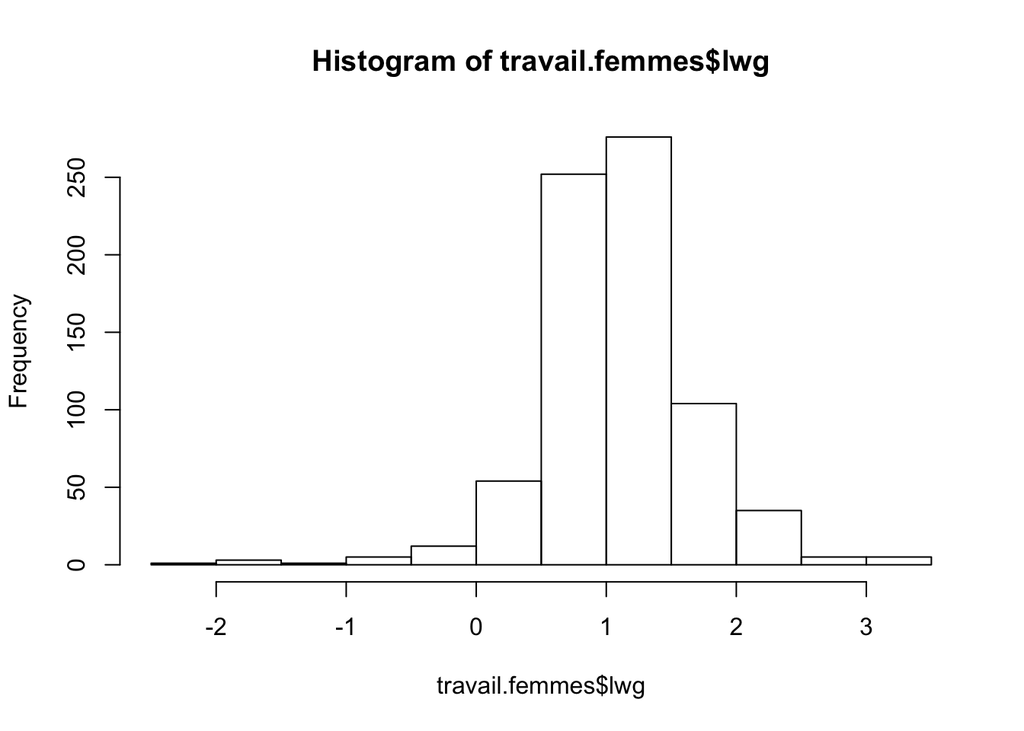

```r
> hist(travail.femmes$lwg)
```

La variable du salaire est souvent exprimée en log, parce que dans la population, la distribution des salaires ne suit souvent pas une distribution normale. Dans la population, il y a généralement quelques individus très fortunés qui représentent une proportion très limitée des travailleurs, alors que la majorité des personnes ont un revenu beaucoup plus bas. Voyez ce à quoi ressemble la distribution réelle des salaires des répondantes de cette enquête:

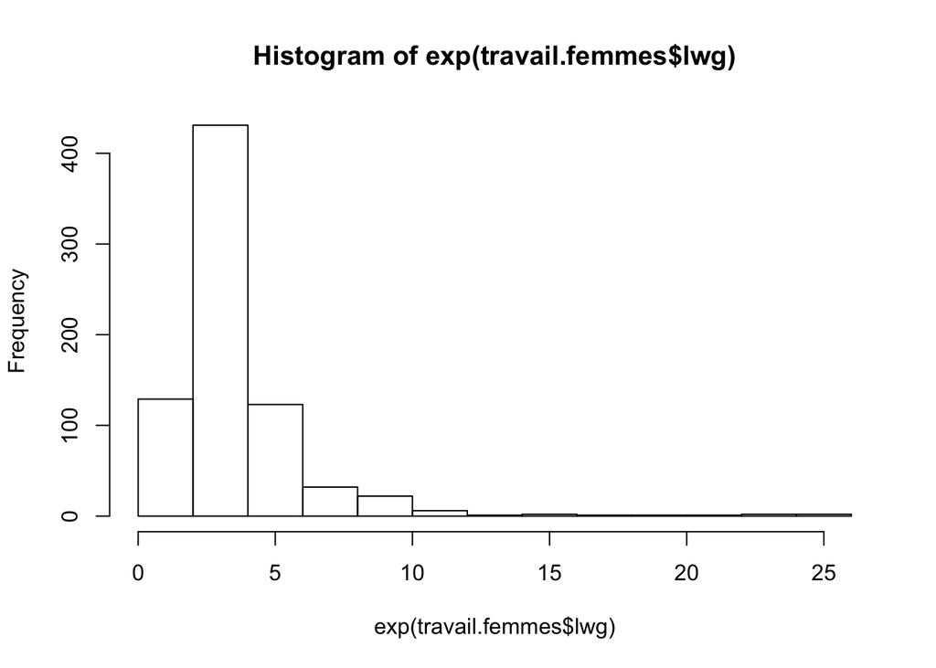

```r
> hist(exp(travail.femmes$lwg))
```

Les chercheurs ayant mené cette étude ont donc utilisé le log pour donner une distribution normale à la variable “salaire”.

Fermons la parenthèse et revenons à notre modèle linéaire. Le nombre d’enfants affecte-t-il négativement le salaire de nos répondantes?

```r
> # Estimation du modèle
> modelelineaire = lm(lwg ~ enfants, data = travail.femmes)
>
> # Résultats
> modelelineaire
```

```
##
## Call:
## lm(formula = lwg ~ enfants, data = travail.femmes)
##
## Coefficients:
## (Intercept)      enfants
##     1.16198     -0.04077
```

```r
>
> # Résultats avec statistiques inférentielles
> summary(modelelineaire)
```

```
##
## Call:
## lm(formula = lwg ~ enfants, data = travail.femmes)
##
## Residuals:
##      Min       1Q   Median       3Q      Max
## -3.09379 -0.27197 -0.02544  0.29874  2.21997
##
## Coefficients:
##             Estimate Std. Error t value Pr(>|t|)
## (Intercept)  1.16198    0.03153  36.851  < 2e-16 ***
## enfants     -0.04077    0.01460  -2.791  0.00538 **
## ---
## Signif. codes:  0 '***' 0.001 '**' 0.01 '*' 0.05 '.' 0.1 ' ' 1
##
## Residual standard error: 0.5849 on 751 degrees of freedom
## Multiple R-squared:  0.01027,    Adjusted R-squared:  0.008951
## F-statistic: 7.792 on 1 and 751 DF,  p-value: 0.00538
```

Portez votre regard sur la colonne `Estimate`. Le coefficient associé à la variable `enfants` est égal à -0.04.

Interprétons: dans cet échantillon de femmes américaines, une augmentation d’un enfant est associé avec une diminution (du log de) de son salaire de 0.04. En bref, une augmentation dans le nombre d’enfants est associé à une diminution du salaire pour ces femmes américaines.

Il est possible que d’autres facteurs expliquent aussi la relation négative entre le nombre d’enfants et le salaire.

- Par exemple, il est possible que les femmes plus âgées aient plus d’enfants (entre autres, parce qu’elles sont nées à une époque où les familles étaient plus nombreuses) *et* qu’elles aient un salaire moins élevés (parce qu’au moment où elles ont intégré le marché du travail, les salaires des femmes étaient encore plus bas).
- D’autre part, il est possible que le niveau d’éducation affecte le nombre d’enfants *ainsi* que le salaire.

La relation entre le nombre d’enfants et le salaire est donc peut-être fallacieuse. Pour vérifier cette possibilité, ajoutons des variables de contrôle à notre modèle: l’**âge de la répondante** et le **fait qu’elle soit allée à l’université**.

```r
> modelecontrole = lm(lwg ~ enfants + age + wc.num, data = travail.femmes)
>
> summary(modelecontrole)
```

```
##
## Call:
## lm(formula = lwg ~ enfants + age + wc.num, data = travail.femmes)
##
## Residuals:
##      Min       1Q   Median       3Q      Max
## -3.13243 -0.24015  0.00586  0.27144  2.33185
##
## Coefficients:
##              Estimate Std. Error t value Pr(>|t|)
## (Intercept)  1.129968   0.141871   7.965 6.15e-15 ***
## enfants     -0.044857   0.016098  -2.787  0.00546 **
## age         -0.001764   0.002918  -0.605  0.54564
## wc.num       0.403371   0.045212   8.922  < 2e-16 ***
## ---
## Signif. codes:  0 '***' 0.001 '**' 0.01 '*' 0.05 '.' 0.1 ' ' 1
##
## Residual standard error: 0.5563 on 749 degrees of freedom
## Multiple R-squared:  0.1072, Adjusted R-squared:  0.1036
## F-statistic: 29.97 on 3 and 749 DF,  p-value: < 2.2e-16
```

Est-ce que la relation négative entre le nombre d’enfants et le salaire tient encore, malgré l’introduction des variables “âge” et “fréquentation de l’université”? Il semblerait que oui. Même en contrôlant l’âge et la fréquentation universitaire, chaque enfant supplémentaire fait diminuer le salaire des répondantes de ce sondage. De plus, cette relation peut être généralisée à la population dont est tiré cet échantillon (p<0.01).

### Exercice 2

Testez une hypothèse de recherche à l’aide des données du *U.S. Women’s Labor-Force Participation*. Composez un modèle de régression linéaire avec au moins une variable de contrôle et interprétez les coefficients ainsi que les niveaux de signification statistique.

## Pour vos projets futurs

Cette introduction à R a effectué un survol des principales fonctionnalités de ce langage, très utile en analyse statistique. Il vous aura appris, je l’espère, à utiliser les fonctions de base en R, à importer des bases de données, à recoder des variables, à utiliser des *packages*, à visualiser vos données et à faire des analyses univariées, bivariées ainsi que des régressions linéaires multivariées. Vous pouvez maintenant utiliser R pour mener d’autres types d’analyses statistiques, comme les régressions logistiques. Je vous invite à explorer les sources citées plus haut si vous avez des questions en cours de cheminement. R est un outil très flexible, vous serez surpris.e des possibilités qui s’ouvrent à vous en termes de modélisation et de visualisation de données!